# Informe TP1_Grupo 3 correcciones.

2023-05-23

# Cargar los paquetes necesarios acá

```r
library(dplyr)
```

```r
library(ggplot2)
```

## Introducción

**Encuesta Uso del tiempo 2016**

Los datos elegidos son los de la encuesta sobre el uso del tiempo correspondiente al año 2016.

Es un relevamiento que realiza Dirección General de Estadística y Censos del Gobierno de la Ciudad de Buenos Aires. Tiene por objeto recoger información sobre el uso del tiempo que los habitantes de la Ciudad dedican a diferentes actividades incluyendo el trabajo remunerado, las actividades domésticas, el cuidado de niños, niñas, personas mayores o con discapacidad, el estudio, el esparcimiento, los viajes y traslados, etc.

Para mayor información sobre la encuesta consultar el [documento metodógico](https://www.estadisticaciudad.gob.ar/eyc/wp-content/uploads/2017/10/UT_CABA_2017.pdf) o la [base usuaia](https://www.estadisticaciudad.gob.ar/eyc/?p=74110).

## Exploración de los datos

Carga de base

```r
encuesta_uso_tiempo_2016 <- read.csv("C:/Users/valum/Downloads/encuesta_uso_tiempo_2016.csv", header = TRUE)
```

Dimensiones

```r
dim(encuesta_uso_tiempo_2016)
```

```
## [1] 2336   27
```

Reconocimiento de variables

```r
names(encuesta_uso_tiempo_2016)
```

```
##  [1] "hogar"                      "sexo"
##  [3] "edad"                       "dia_laborable"
##  [5] "trabajo_pago"               "trabajo_domestico_no_pago"
##  [7] "voluntariados"              "estudio_educacion"
##  [9] "recreacion"                 "aplicaciones"
## [11] "tareas_cuidados"            "cuidado_personal"
## [13] "trabajo_pago2"              "trabajo_domestico_no_pago2"
## [15] "voluntariados2"             "estudio_educacion2"
## [17] "recreacion2"                "aplicaciones2"
## [19] "tareas_cuidados2"           "cuidado_personal2"
## [21] "dia_tipico"                 "rango_etario"
## [23] "nivel_educativo"            "relacion_parentesco_jefe"
## [25] "tipo_hogar"                 "quintil_ingreso"
## [27] "estado_ocupacional"
```

La base de datos de referencia consta de 27 variables y 2336 observaciones.

Variables:

- hogar
- sexo
- edad
- dia_laborable
- trabajo_pago
- trabajo_domestico_no_pago
- voluntariados
- estudio_educacion
- recreacion
- aplicaciones
- tareas_cuidados
- cuidado_personal
- trabajo_pago2
- trabajo_domestico_no_pago2
- voluntariados2
- estudio_educacion2
- recreacion2
- aplicaciones2
- tareas_cuidados2
- cuidado_personal2
- dia_tipico
- rango_etario
- nivel_educativo
- relacion_parentesco_jefe
- tipo_hogar
- quintil_ingreso
- estado_ocupacional

Del listado de variables vamos a considerar para anlizar las variables “sexo”, “trabajo_domestico_no_pago” y “trabajo_pago”.

**Trabajo doméstico no pago según sexo**

```r
encuesta_uso_tiempo_2016%>%
  group_by(sexo)%>%
summarise(Promedio = mean(trabajo_domestico_no_pago),
          DesvStandard = sd(trabajo_domestico_no_pago),
          min(trabajo_domestico_no_pago),
          max(trabajo_domestico_no_pago))
```

```
## # A tibble: 2 × 5
##   sexo  Promedio DesvStandard min(trabajo_domestico_no_…¹ max(trabajo_domestic…²
##   <chr>    <dbl>        <dbl>                       <dbl>                  <dbl>
## 1 Mujer     3.14         2.66                           0                   15.7
## 2 Varon     1.81         1.97                           0                   12
## # ℹ abbreviated names: ¹`min(trabajo_domestico_no_pago)`,
## #   ²`max(trabajo_domestico_no_pago)`
```

Las mujeres dedican mayor tiempo diario al trabajo domestico que los varones. La media de las mujeres es de 3,1hs, mientras que la media de los varones es de 1,8hs.

En el caso de las mujeres los valores para la variable “trabajo doméstico no pago” van desde 0hs hasta 15,7hs. Mientras que el rango de los varones es de 0hs a 12hs.

**Trabajo pago según sexo**

```r
encuesta_uso_tiempo_2016%>%
  group_by(sexo)%>%
summarise(Promedio=mean(trabajo_pago),
          DesvStandard=sd(trabajo_pago),
          min(trabajo_pago),
          max(trabajo_pago))
```

```
## # A tibble: 2 × 5
##   sexo  Promedio DesvStandard `min(trabajo_pago)` `max(trabajo_pago)`
##   <chr>    <dbl>        <dbl>               <dbl>               <dbl>
## 1 Mujer     3.48         4.47                   0                18.5
## 2 Varon     5.27         5.00                   0                22.5
```

Se observa que los varones dedican más tiempo diario al trabajo remunerado que las mujeres. Siendo la media de los varones 5,2hs y la de las mujeres 3,4hs diarias.

En el caso del trabajo remunerado el rango en las mujeres es de 0hs hasta 18,5hs, y para los varones es de 0hs a 22.5hs.

## Hipótesis

Existe una relación desigual en la distribución del uso del tiempo entre varones y mujeres, la cual se puede observar al ver el tipo de trabajo (productivo=pago, no reproductivo=doméstico no pago). Siendo las mujeres quienes dedican mayor tiempo diario a las tareas domésticas, mientras que los varones dedican mayor tiempo al trabajo productivo.

Esto puede verse justificado a partir de la división sexual del trabajo y los roles de géneros de las sociedades modernas.

Pero ¿como se dan esas diferencias según grupos etarios? ¿que particularidades se pueden observar al tomar en consideración el trabajo del cuidado a miembros del hogar no pago? ¿Existe una sobrecarga de trabajo para las mujeres aún cuando también realizan tareas laborales remuneradas?

Nuestra hipótesis sostiene que al contraponer el tiempo de “trabajo productivo” (trabajo pago) con el “trabajo reproductivo” (tiempo destinado a las tareas vinculadas al trabajo domestico y al cuidado de miembros del hogar), resultan ser las mujeres quienes dedican más horas de su día al trabajo que los varones. Implicando una sobrecarga de trabajo invisibilizada.

## TP2

## Visualizaciones:

**Tabajo pago según sexo**

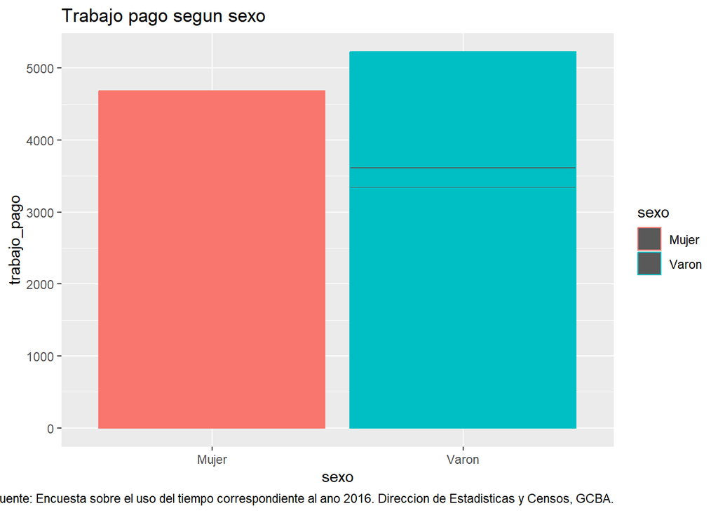

```r
encuesta_uso_tiempo_2016 %>%
ggplot(aes(sexo, trabajo_pago)) +
  geom_col(aes(color=sexo)) +
  labs(title = "Trabajo pago segun sexo",
      caption = "Fuente: Encuesta sobre el uso del tiempo correspondiente al ano 2016. Direccion de Estadisticas y Censos, GCBA.")
```

Al graficar la variable “trabajo pago” según sexo, se observa que es mayor la cantidad de horas que le dedican los varones que las mujeres.

**Trabajo pago doméstico no pago según sexo**

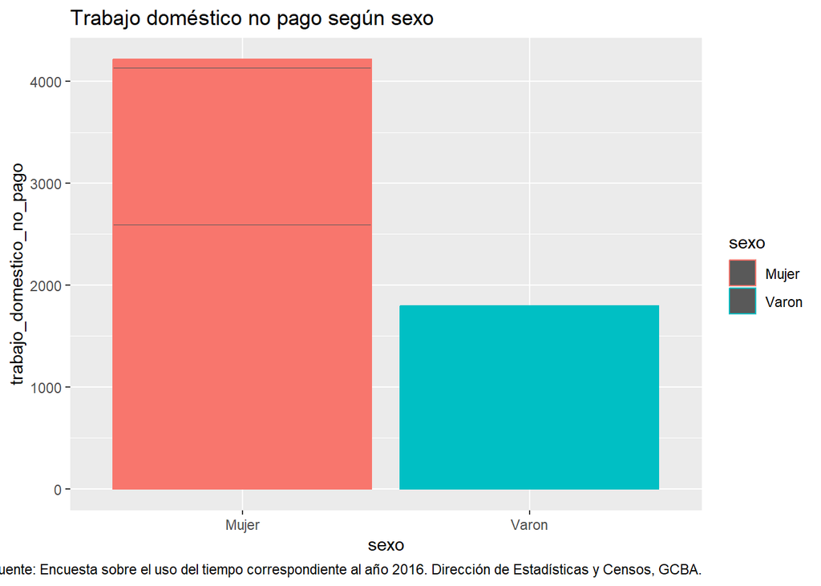

```r
encuesta_uso_tiempo_2016 %>%
ggplot(aes(sexo, trabajo_domestico_no_pago)) +
  geom_col(aes(color=sexo)) +
  labs(title = "Trabajo doméstico no pago según sexo",
       caption = "Fuente: Encuesta sobre el uso del tiempo correspondiente al año 2016. Dirección de Estadísticas y Censos, GCBA.")
```

La cantidad de horas que le dedican las mujeres a realizar tareas doméstica es significativamente mayor que el que le dedican los varones.

**Trabajo reproductivo** Entendiendo que el “trabajo reproductivo” es aquel destinado a garantizar la satisfacción de las necesidades de los miembros del hogar, asumiendo la forma de tareas de cuidados y tareas domésticas que no son remuneradas, se contruyó la varibale denominada “trabajo_reproductivo” incluyendo “tareas_cuidados” y “trabajo_domestico_no_pago”.

```r
encuesta_uso_tiempo_2016_b <- encuesta_uso_tiempo_2016 %>%
  mutate(trabajo_reproductivo = trabajo_domestico_no_pago + tareas_cuidados)
```

**Trabajo reproductivo según sexo**

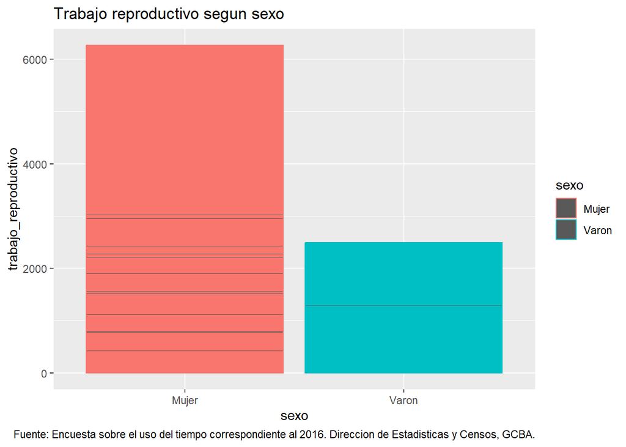

```r
encuesta_uso_tiempo_2016_b %>%
ggplot(aes(sexo, trabajo_reproductivo)) +
  geom_col(aes(color=sexo)) +
  labs(title = "Trabajo reproductivo segun sexo",
       caption = "Fuente: Encuesta sobre el uso del tiempo correspondiente al 2016. Direccion de Estadisticas y Censos, GCBA.")
```

Al incluir las tareas del cuidado al trabajo no remunerado, se observa que es mayor la brecha entre varones y mujeres en cuanto a la distribución del tiempo del trabajo reproductivo.

Trabajo reproductivo segun edad y sexo:

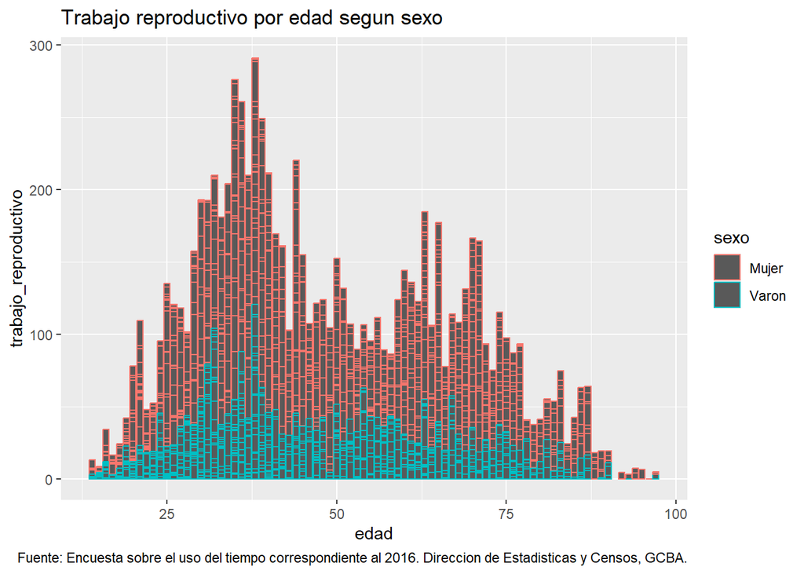

```r
encuesta_uso_tiempo_2016_b %>%
ggplot(aes(edad, trabajo_reproductivo)) +
  geom_col(aes(color=sexo)) +
  labs(title = "Trabajo reproductivo por edad segun sexo",
       caption = "Fuente: Encuesta sobre el uso del tiempo correspondiente al 2016. Direccion de Estadisticas y Censos, GCBA.")
```

Trabajo pago segun edad y sexo:

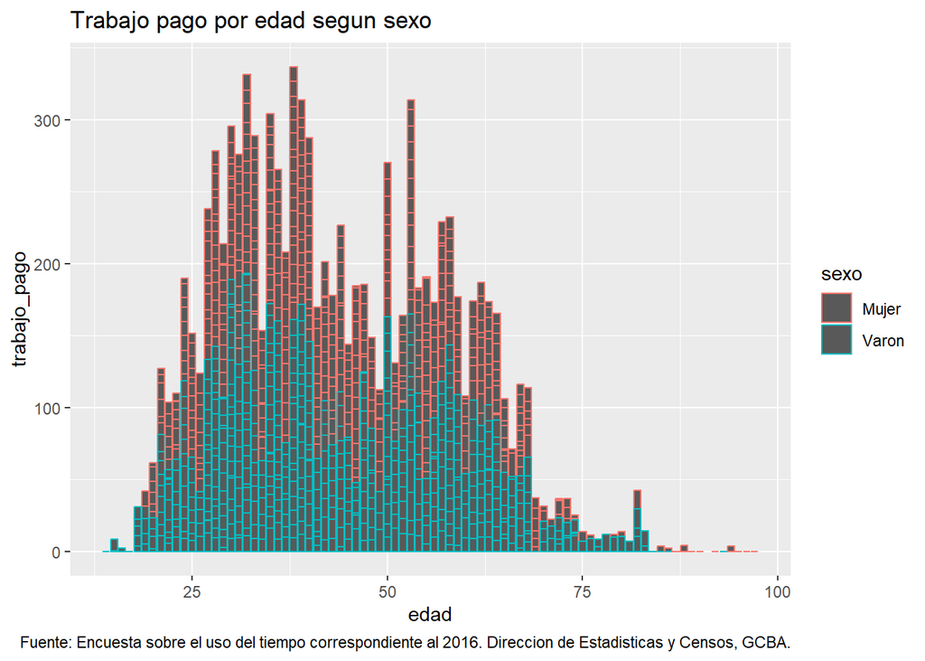

```r
encuesta_uso_tiempo_2016_b %>%
ggplot(aes(edad, trabajo_pago)) +
  geom_col(aes(color=sexo)) +
  labs(title = "Trabajo pago por edad segun sexo",
       caption = "Fuente: Encuesta sobre el uso del tiempo correspondiente al 2016. Direccion de Estadisticas y Censos, GCBA.")
```